# mice_package

newbiettn

19 December 2016

This is a research experiment of using `mice` package (Buuren and Groothuis-Oudshoorn, 2011) to impute missing values in multivariate data. Basically, `mice` uses **Fully Conditional Specification (FCS)** method, whereas *chained equation* is simply an alias of that term. According to (Liu and De, 2015), FCS is more relaxed than the conventional method Joint Modeling (JM) in terms of specifiying distribution of the missing data.

In this experiment, we will employ an open source dataset **Titanic** to carry the experiment.

#### 1. Multiple imputation vs Single imputation

Both multiple and single imputation techniques are ones that can be used to replace missing values in the data by plausible values. In single imputation, we substitute the missing values of the data by **a single value**. For example, we can replace missing values of a variable by the most common value, or the *mean/median* value (in case that variable is continuous). Multiple imputation is different in a sense that missing values are replaced by **multiple plausible values**. Using `mice` package, we can even have multiple version of imputed data by trying to impute the data more than one time.

#### 2. Notation

- $\mathbf{Y_j}$ $(j = 1,..., p)$: one of $p$ incomplete variables.
- The observed and missing parts of $Y_j$ are denoted by $\mathbf{Y_j^{obs}}$ and $\mathbf{Y_j^{mis}}$.
  - $Y^{obs} = (Y^{obs},...,Y^{obs}_p)$: observed data in Y.
  - $Y^{mis} = (Y^{mis},...,Y^{mis}_p)$: missing data in Y.
- $\mathbf{m \ge 1}$: the number of imputation.
- $\mathbf{Q}$: predicted model that would be trained on $Y$.

#### 3. Features

`mice` introduces a *modular approach* to impute data. The imputation framework offered by `mice` comprises of 3 steps: *imputation*, *analysis* and *pooling*.

- `mice()` Impute incomplete data, creating imputed versions of the data $Y^{(1)}$, $Y^{(2)}$, …, $Y^{(m)}$.
- `with()` Estimate the predicted model $Q$ on each imputed dataset $Y^{(i)}$, creating multiple versions of the model, which are $\hat{Q}^{(1)}$, $\hat{Q}^{(2)}$,…, $\hat{Q}^{(m)}$
- `pool` Pool $\hat{Q}^{(1)}$, $\hat{Q}^{(2)}$,…, $\hat{Q}^{(m)}$ into one estimates $\bar{Q}$

A notable feature of this imputation model is that we use our predicted model of interest $Q$ to analyse the imputed data by ourself. By doing that, we can specifically select the best imputed data that suits our investigation.

#### 4. Experiment

#### 4.1. Missing value inspection

First and foremost, load the package and data. In this experiment, we will use Titanic data free available from Kaggle.

```r
# Load library
library(mice) # Imputation
library(VIM) #aggr, marginplot
library(lattice) #stripplot
# Load data
dt <- read.csv("data/titanic.csv", na.strings = c("NA", ""))
str(dt) # Inspect the data structure
```

```
## 'data.frame':    891 obs. of  12 variables:
##  $ PassengerId: int  1 2 3 4 5 6 7 8 9 10 ...
##  $ Survived   : int  0 1 1 1 0 0 0 0 1 1 ...
##  $ Pclass     : int  3 1 3 1 3 3 1 3 3 2 ...
##  $ Name       : Factor w/ 891 levels "Abbing, Mr. Anthony",..: 109 191 358 277 16 559 520 629 417 581 ...
##  $ Sex        : Factor w/ 2 levels "female","male": 2 1 1 1 2 2 2 2 1 1 ...
##  $ Age        : num  22 38 26 35 35 NA 54 2 27 14 ...
##  $ SibSp      : int  1 1 0 1 0 0 0 3 0 1 ...
##  $ Parch      : int  0 0 0 0 0 0 0 1 2 0 ...
##  $ Ticket     : Factor w/ 681 levels "110152","110413",..: 524 597 670 50 473 276 86 396 345 133 ...
##  $ Fare       : num  7.25 71.28 7.92 53.1 8.05 ...
##  $ Cabin      : Factor w/ 147 levels "A10","A14","A16",..: NA 82 NA 56 NA NA 130 NA NA NA ...
##  $ Embarked   : Factor w/ 3 levels "C","Q","S": 3 1 3 3 3 2 3 3 3 1 ...
```

```r
# Remove unnecessary columns
dt[, c("PassengerId", "Name", "Cabin", "Ticket")] <- NULL
summary(dt) # Summary the data
```

```
##     Survived          Pclass          Sex           Age
##  Min.   :0.0000   Min.   :1.000   female:314   Min.   : 0.42
##  1st Qu.:0.0000   1st Qu.:2.000   male  :577   1st Qu.:20.12
##  Median :0.0000   Median :3.000                Median :28.00
##  Mean   :0.3838   Mean   :2.309                Mean   :29.70
##  3rd Qu.:1.0000   3rd Qu.:3.000                3rd Qu.:38.00
##  Max.   :1.0000   Max.   :3.000                Max.   :80.00
##                                                NA's   :177
##      SibSp           Parch             Fare        Embarked
##  Min.   :0.000   Min.   :0.0000   Min.   :  0.00   C   :168
##  1st Qu.:0.000   1st Qu.:0.0000   1st Qu.:  7.91   Q   : 77
##  Median :0.000   Median :0.0000   Median : 14.45   S   :644
##  Mean   :0.523   Mean   :0.3816   Mean   : 32.20   NA's:  2
##  3rd Qu.:1.000   3rd Qu.:0.0000   3rd Qu.: 31.00
##  Max.   :8.000   Max.   :6.0000   Max.   :512.33
##
```

```r
# Fare = 0 doesn't make sense, set 0 values in Fare as missing values
dt$Fare[dt$Fare == 0] <- NA
```

Our data contains a lot of missing values. We will use different methods to inspect them. First, we will use `md.pattern` method to inspect missing-data patterns.

```r
md.pattern(dt)
```

```
##     Survived Pclass Sex SibSp Parch Embarked Fare Age
## 705        1      1   1     1     1        1    1   1   0
## 169        1      1   1     1     1        1    1   0   1
##   7        1      1   1     1     1        1    0   1   1
##   2        1      1   1     1     1        0    1   1   1
##   8        1      1   1     1     1        1    0   0   2
##            0      0   0     0     0        2   15 177 194
```

Let’s intepret information from the retrieved table. Note that in the table, 0 represents missing in the data. Look at the table by row, the table tells us that we have 705 complete rows, 169 rows where only `Age` is missing, `7` rows where only `Fare` is missing, 2 rows where `Embarked` is missing, and 8 rows where both `Fare` and `Age` are missing. Vertically, the tables tells us that `Embarked` has 2 missing values, `Fare` 15, and `Age` 177. In overall, we have 194 missing values in the data, and 169 + 7 + 2 + 8 = 186 incomplete rows.

Besides `md.pattern`, we can visually inspect missing patterns of the data using the package `VIM`. First, we will use `aggr` to aggregate missing values.

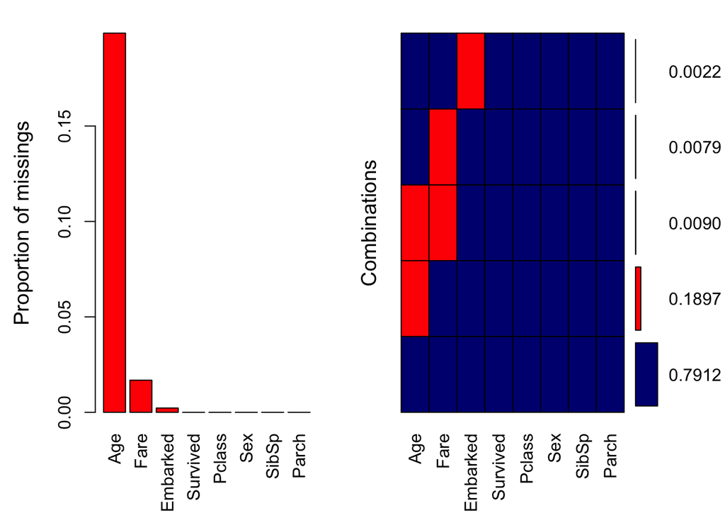

```
##
##  Variables sorted by number of missings:
##  Variable       Count
##       Age 0.198653199
##      Fare 0.016835017
##  Embarked 0.002244669
##  Survived 0.000000000
##    Pclass 0.000000000
##       Sex 0.000000000
##     SibSp 0.000000000
##     Parch 0.000000000
```

```r
aggr(dt, col = c("navyblue","red"), sortVars = TRUE, numbers = TRUE)
```

The method `aggr` is essentially similar to `md.patterns`, except that `aggr` displays missing values in portion. For example, roughly 20% (177 rows) of `Age` are incomplete, 1.6% (15 rows) of `Fare` missing, and 0.2% (2 rows) of `Embarked` missing. There are roughly 0.9% (8 rows) of the data where both `Age` and `Fare` are missing. Thus, it seems more convenient when combine both `md.pattern` and `aggr` together to inspect missing values of the data.

We can also observe missing values by pair. The function `marginplot` is perfect for this purpose. We will use `marginplot` to inspect missing patterns of the pair `Age` and `Fare`.

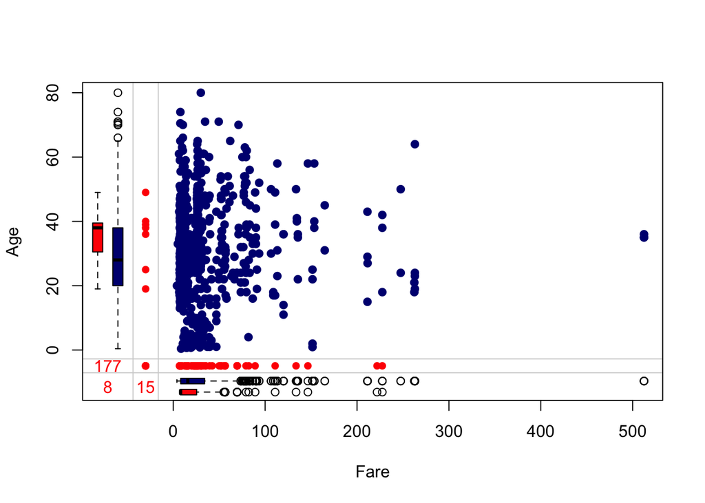

```r
marginplot(dt[, c("Fare", "Age")], col = c("navyblue", "red"), numbers = TRUE, pch = 19)
```

##### 4.2. Data imputation with `mice()`

We can simply impute the data by using the function `mice()`. For example,

```r
# Impute missing values
imp <- mice(dt, maxit = 20)
```

By default, `mice()` will create **5 version of imputed data** (i.e., `m = 5`), and for each version, the default number of iterations is also 5 (i.e., `maxit = 5`). According to the authors, the convergence of Gibbs sampling often happens when `maxit` is between 10 and 20.

```r
# Extract the 1st version of the imputed data using complete()
dt_imp_1 <- complete(imp, 1)
summary(dt_imp_1)
```

```
##     Survived          Pclass          Sex           Age
##  Min.   :0.0000   Min.   :1.000   female:314   Min.   : 0.42
##  1st Qu.:0.0000   1st Qu.:2.000   male  :577   1st Qu.:20.00
##  Median :0.0000   Median :3.000                Median :29.00
##  Mean   :0.3838   Mean   :2.309                Mean   :29.37
##  3rd Qu.:1.0000   3rd Qu.:3.000                3rd Qu.:39.00
##  Max.   :1.0000   Max.   :3.000                Max.   :80.00
##      SibSp           Parch             Fare         Embarked
##  Min.   :0.000   Min.   :0.0000   Min.   :  4.013   C:168
##  1st Qu.:0.000   1st Qu.:0.0000   1st Qu.:  7.925   Q: 77
##  Median :0.000   Median :0.0000   Median : 14.500   S:646
##  Mean   :0.523   Mean   :0.3816   Mean   : 32.595
##  3rd Qu.:1.000   3rd Qu.:0.0000   3rd Qu.: 31.137
##  Max.   :8.000   Max.   :6.0000   Max.   :512.329
```

We can see that missing values no longer exist in the data. Let’s see how the data is imputed across 5 versions. First begin with `Embarked`

```r
# Embarked
idx <- which(is.na(dt$Embarked)) # get index of missing values in the original data
sapply(c(1:5), function(x) {(complete(imp, x)$Embarked[idx])})
```

```
##      [,1] [,2] [,3] [,4] [,5]
## [1,] "S"  "C"  "S"  "S"  "S"
## [2,] "S"  "S"  "S"  "C"  "S"
```

So, `mice()` imputed missing values in `Embarked` with different values. Note that in the original data, there are 644 rows of `S`. So I suspect the imputed values are likely (S,S).

Next, we will explore the distribution of imputed values of `Age` and `Fare`. It can be seen from both plots that the distribution of imputed values are similar to that of observed values.

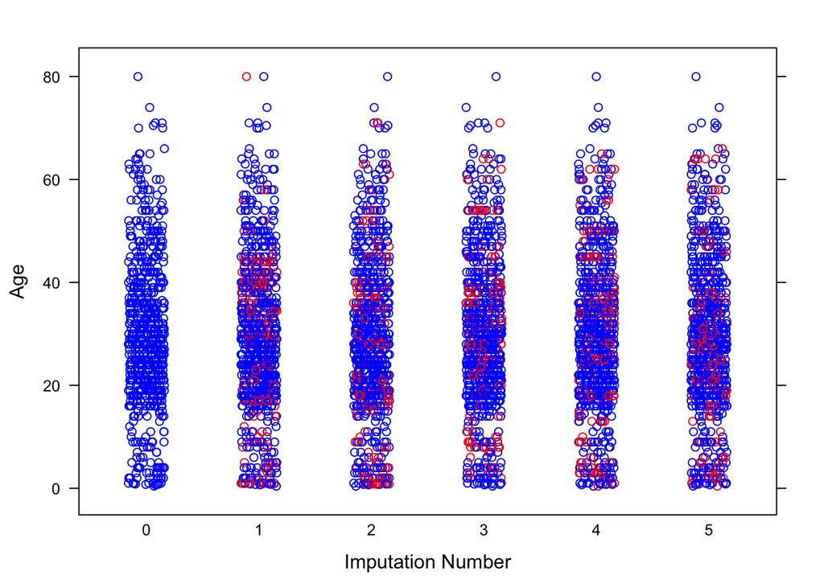

```r
# Age
dt_imp_1 <- complete(imp, "long", inc = TRUE)
col <- rep(c("blue", "red")[1+as.numeric(is.na(imp$data$Age))], 6)
stripplot(Age~.imp, data = dt_imp_1, jit = TRUE, fac = 0.8, col = col, xlab = "Imputation Number")
```

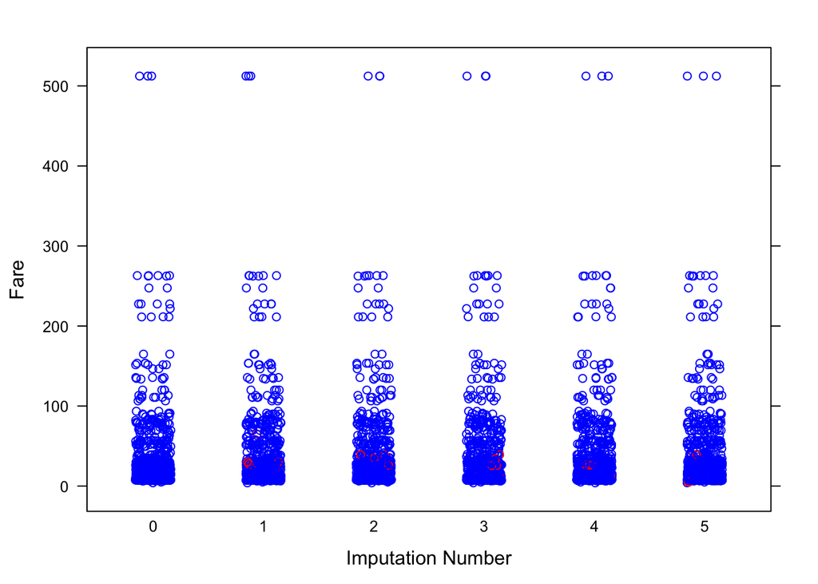

```r
# Fare
col <- rep(c("blue", "red")[1+as.numeric(is.na(imp$data$Fare))], 6)
stripplot(Fare~.imp, data = dt_imp_1, jit = TRUE, fac = 0.8, col = col, xlab = "Imputation Number")
```

##### 4.2. Data analysis with `with()`

After imputation, we will analyse imputed data using `with()`. As said, we analyse the imputed data by our predict model of interest $Q$.

```r
fit <- with(imp, glm(Survived ~ Sex + Age + Fare + Pclass + SibSp + Parch + Embarked,
                     family = "binomial"))
```

##### 4.3. Result pooling with `pool()`

```r
pool(fit)
```

```
## Call: pool(object = fit)
##
## Pooled coefficients:
##  (Intercept)         Sex2          Age         Fare       Pclass
##  5.621210576 -2.721461044 -0.042058646  0.001139207 -1.220823916
##        SibSp        Parch    Embarked2    Embarked3
## -0.373369245 -0.070237575 -0.023930646 -0.386734943
##
## Fraction of information about the coefficients missing due to nonresponse:
## (Intercept)        Sex2         Age        Fare      Pclass       SibSp
## 0.445502454 0.010339489 0.602587359 0.037762196 0.302746674 0.079330216
##       Parch   Embarked2   Embarked3
## 0.006668691 0.148825704 0.008111020
```

```r
summary(pool(fit))
```

```
##                      est         se            t        df     Pr(>|t|)
## (Intercept)  5.621210576 0.74456535   7.54965377  23.78279 9.190997e-08
## Sex2        -2.721461044 0.20319957 -13.39304518 860.77809 0.000000e+00
## Age         -0.042058646 0.01086454  -3.87118614  12.99189 1.930650e-03
## Fare         0.001139207 0.00238144   0.47836910 674.66795 6.325425e-01
## Pclass      -1.220823916 0.17687061  -6.90235597  48.90825 9.482792e-09
## SibSp       -0.373369245 0.11347692  -3.29026580 382.21011 1.093920e-03
## Parch       -0.070237575 0.11953689  -0.58758076 872.44999 5.569658e-01
## Embarked2   -0.023930646 0.42212266  -0.05669122 163.57709 9.548604e-01
## Embarked3   -0.386734943 0.23804301  -1.62464314 868.42263 1.046015e-01
##                    lo 95        hi 95 nmis         fmi      lambda
## (Intercept)  4.083760163  7.158660990   NA 0.445502454 0.400753849
## Sex2        -3.120285671 -2.322636417   NA 0.010339489 0.008042702
## Age         -0.065531540 -0.018585751  177 0.602587359 0.545781236
## Fare        -0.003536718  0.005815133   15 0.037762196 0.034913940
## Pclass      -1.576275582 -0.865372250    0 0.302746674 0.274805267
## SibSp       -0.596486448 -0.150252042    0 0.079330216 0.074525177
## Parch       -0.304851045  0.164375895    0 0.006668691 0.004394190
## Embarked2   -0.857442448  0.809581155   NA 0.148825704 0.138481928
## Embarked3   -0.853941824  0.080471938   NA 0.008111020 0.005829301
```

#### 5. Convergence assessment

Convergence assessment of Gibbs sampling algorithm is important to check that if the algorithm is converged. According to the paper: *“There is no clear-cut method for determining whether the Gibbs sampling algorithm has converged. What is often done is to plot one or more parameters against the iteration number”* and *“on convergence, the different streams should be freely intermingled with each other, without showing any definite trends. Convergence is diagnosed when the variance between different sequences is no larger than the variance with each individual sequence”*.

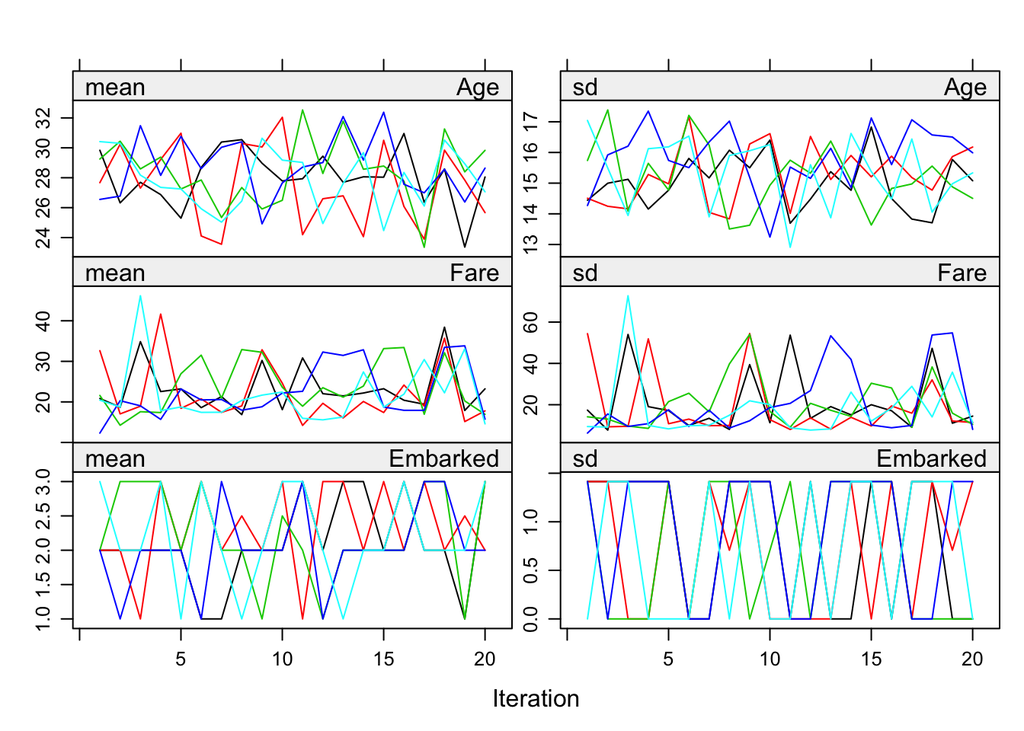

```r
plot(imp)
```

#### References

Buuren, S. & Groothuis-Oudshoorn, K. (2011, December). MICE: Multivariate Imputation by Chained Equations in R. Journal of Statistical Software, 45(3), 1–67. Retrieved from http://doc.utwente.nl/78938/

Liu, Y. & De, A. (2015, July). Multiple Imputation by Fully Conditional Spe- cification for Dealing with Missing Data in a Large Epidemiologic Study. International Journal of Statistics in Medical Research, 4(3), 287–295. doi:10.6000/1929-6029.2015.04.03.7